# Praktické a teoretické znalosti vybraných statistických metod

## Vizualizace dat (Histogram s hustotou)

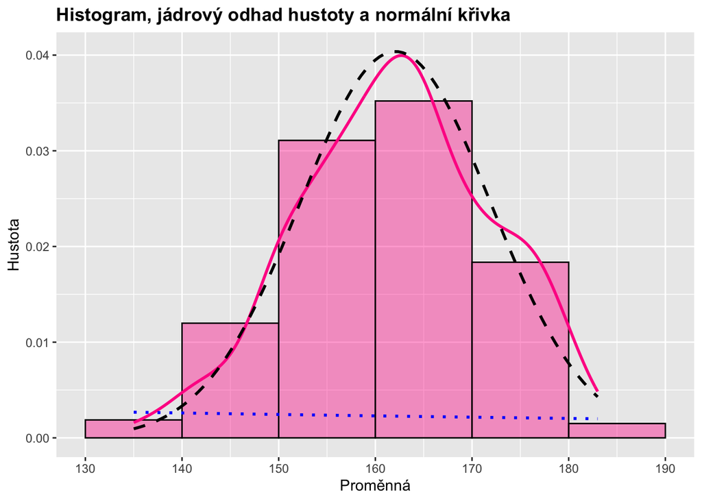

```r
promenna <- df$VYSKA

mean <- mean(promenna, na.rm = TRUE)
sd <- sd(promenna, na.rm = TRUE)


df %>%
  ggplot(aes(x = VYSKA)) +

  geom_histogram(breaks = seq(130, 190, 10),
                 color = "black",
                 fill = "deeppink",
                 aes(y = after_stat(density)),
                 alpha = 0.4) +

  geom_density(color = "deeppink", size = 1) +

  stat_function(fun = dnorm, args = list(mean = mean, sd = sd),
                color = "black", size = 1, linetype = "dashed") +

  stat_function(fun = dexp, args = list(rate = 1/mean(promenna, na.rm = TRUE)),
                color = "blue", size = 1, linetype = "dotted") +

  scale_x_continuous(breaks = seq(130, 190, 10)) +
  labs(title = "Histogram, jádrový odhad hustoty a normální křivka",
       x = "Proměnná",
       y = "Hustota") +
  theme(plot.title = element_text(face = "bold"))
```

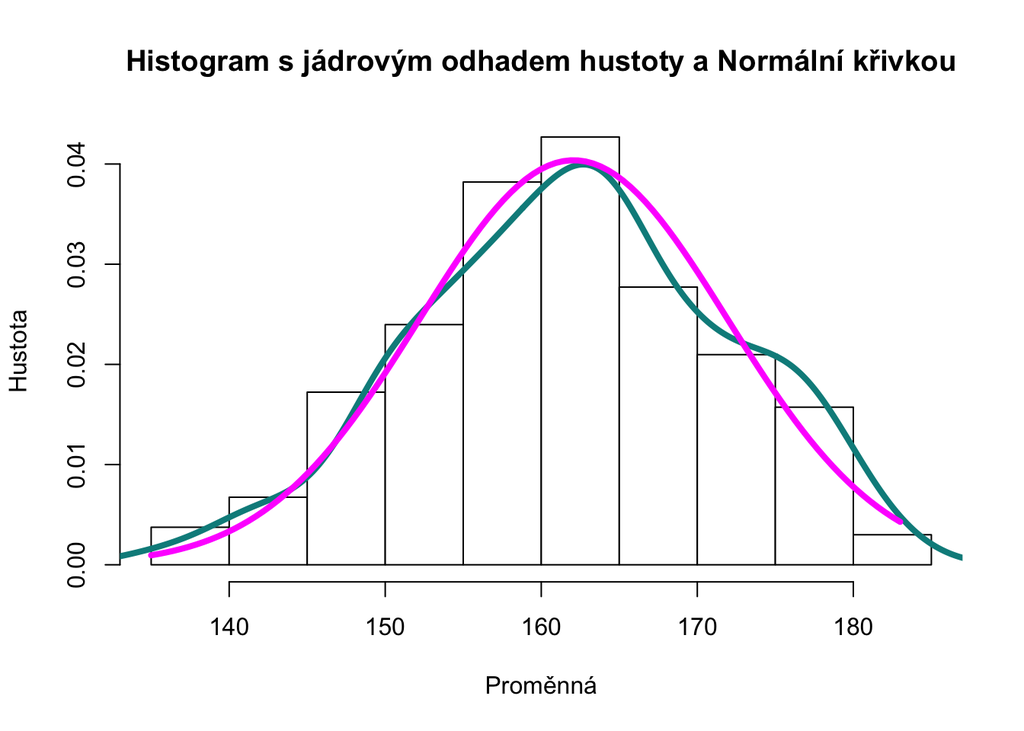

```r
promenna <- df$VYSKA

# 1. Histogram (s hustotou)
hist(promenna, breaks=10, col="white", xlab="Proměnná", ylab="Hustota",
     main="Histogram s jádrovým odhadem hustoty a Normální křivkou", freq = F)

# 2. Jádrový odhad hustoty
lines(density(promenna), col = "darkcyan", lwd = 4)

# 3. Normální křivka
curve(dnorm(x, mean = mean(promenna), sd = sd(promenna)),
      from = min(promenna), to = max(promenna), col = "magenta", lwd = 4, add = TRUE)
```

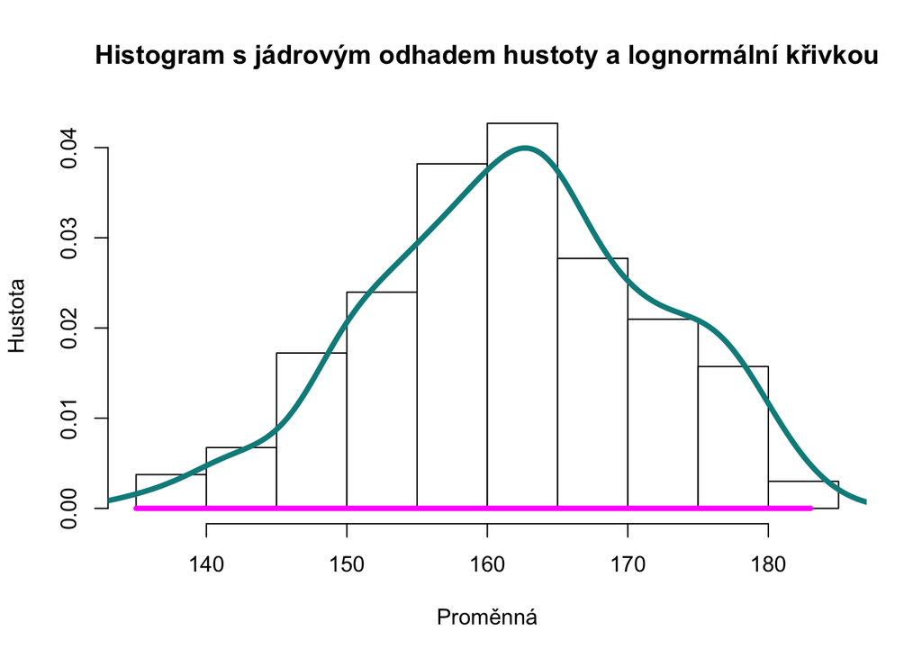

```r
promenna <- df$VYSKA

# 1. Histogram (s hustotou)
hist(promenna, breaks=10, col="white", xlab="Proměnná", ylab="Hustota",
     main="Histogram s jádrovým odhadem hustoty a lognormální křivkou", freq = F)

# 2. Jádrový odhad hustoty
lines(density(promenna), col = "darkcyan", lwd = 4)

# 3. Lognormální křivka
curve(dnorm(log(x), mean = mean(promenna), sd = sd(promenna)),
      from = min(promenna), to = max(promenna), col = "magenta", lwd = 4, add = TRUE)
```

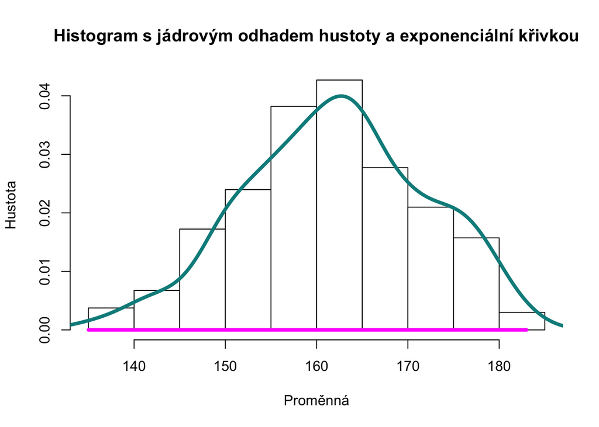

```r
promenna <- df$VYSKA

# 1. Histogram (s hustotou)
hist(promenna, breaks=10, col="white", xlab="Proměnná", ylab="Hustota",
     main="Histogram s jádrovým odhadem hustoty a exponenciální křivkou", freq = F)

# 2. Jádrový odhad hustoty
lines(density(promenna), col = "darkcyan", lwd = 4)

# 3. Exponenciální křivka
mean <- 1/mean(promenna)
lambda <- 1/mean
curve(dexp(x, rate = lambda),
      from = min(promenna), to = max(promenna), col = "magenta", lwd = 4, add = TRUE)
```

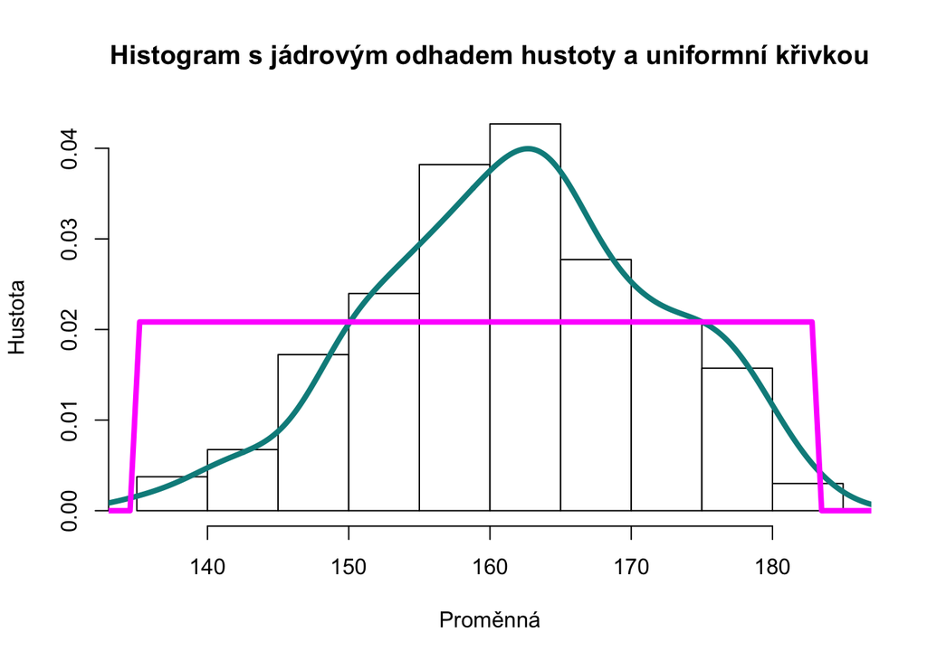

```r
promenna <- df$VYSKA

# 1. Histogram (s hustotou)
hist(promenna, breaks=10, col="white", xlab="Proměnná", ylab="Hustota",
     main="Histogram s jádrovým odhadem hustoty a uniformní křivkou", freq = F)

# 2. Jádrový odhad hustoty
lines(density(promenna), col = "darkcyan", lwd = 4)

# 3. Uniformní křivka
curve(dunif(x, min = min(promenna), max = max(promenna)),
      from = min(promenna) - 10, to = max(promenna) + 10, col = "magenta", lwd = 4, add = TRUE)
```

## Vizualizace - diskrétní příklady barplotů

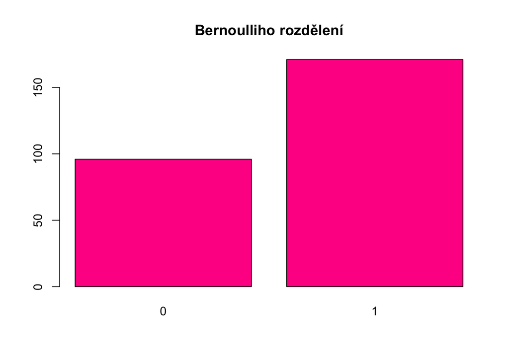

```r
promenna <- df$POHLA
frekvence <- table(promenna)
pravdepodobnost <- prop.table(frekvence)
barplot(frekvence, col="deeppink", main = "Bernoulliho rozdělení")
```

**Binomické rozdělení**

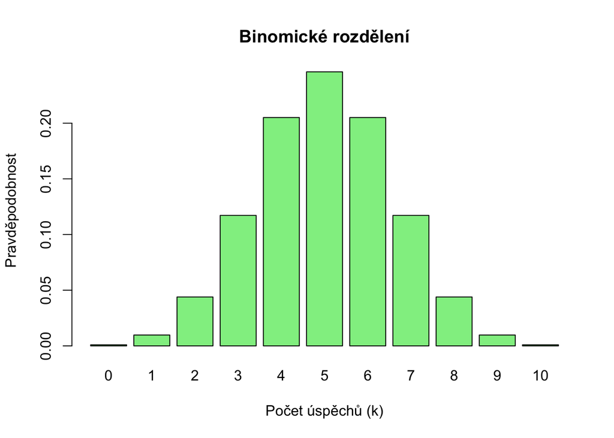

```r
n <- 10  # Počet pokusů
p <- 0.5  # Pravděpodobnost úspěchu

# Hodnoty X a jejich pravděpodobnosti
x <- 0:n
prob <- dbinom(x, size = n, prob = p)

# Graf
barplot(prob, names.arg = x, col = "lightgreen", main = "Binomické rozdělení",
        xlab = "Počet úspěchů (k)", ylab = "Pravděpodobnost")
```

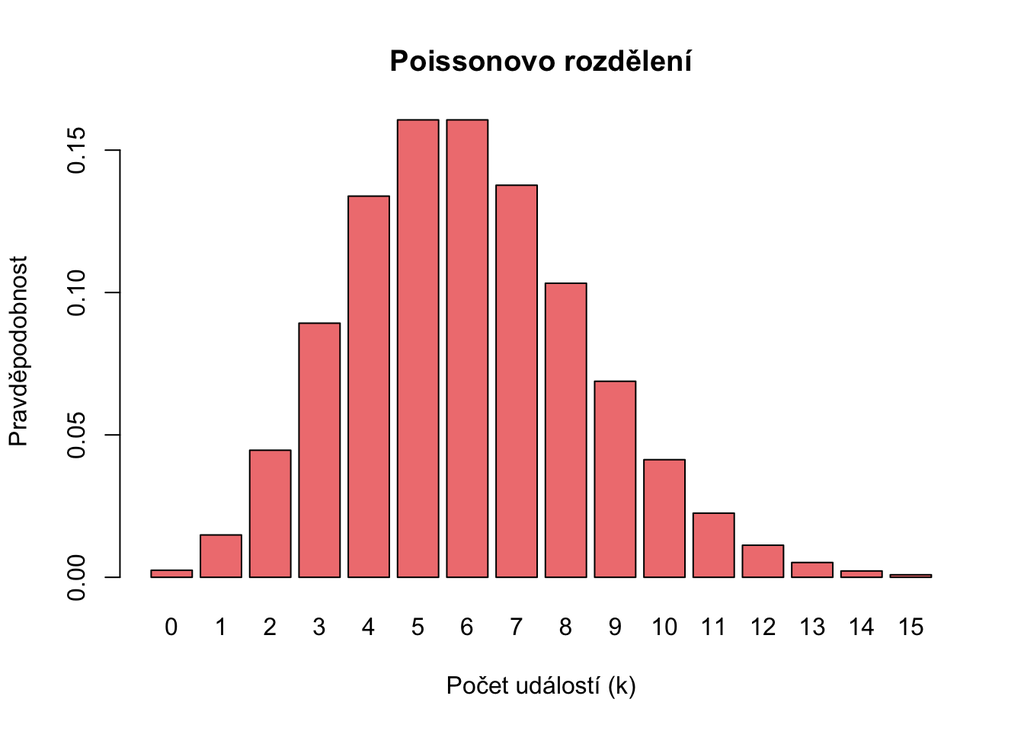

```r
lambda <- 6  # Střední počet událostí

x <- 0:15  # Rozsah X
prob <- dpois(x, lambda = lambda)

# Graf
barplot(prob, names.arg = x, col = "lightcoral", main = "Poissonovo rozdělení",
        xlab = "Počet událostí (k)", ylab = "Pravděpodobnost")
```

**Geometrické rozdělení**

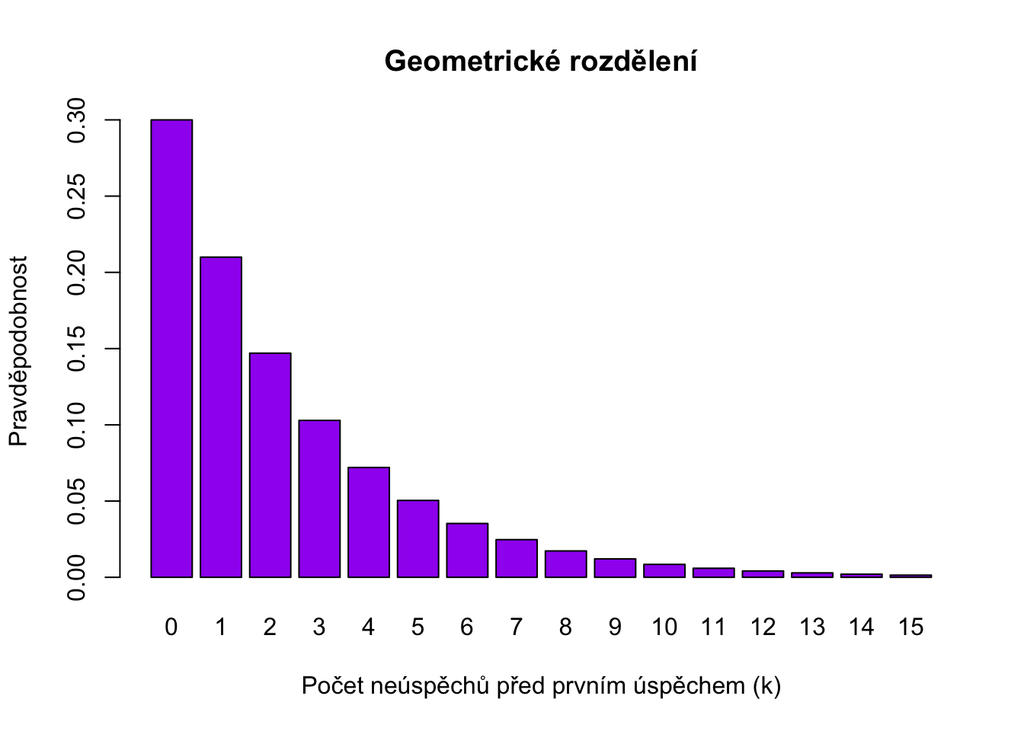

```r
p <- 0.3  # Pravděpodobnost úspěchu

# Hodnoty X a jejich pravděpodobnosti
x <- 0:15
prob <- dgeom(x, prob = p)

# Graf
barplot(prob, names.arg = x, col = "purple", main = "Geometrické rozdělení",
        xlab = "Počet neúspěchů před prvním úspěchem (k)", ylab = "Pravděpodobnost")
```

## AIC, BIC

- **Složité** To, co má **nižší** AIC, BIC je vhodnější rozdělení
- **AIC** … metoda co vybírá mezi modely, cílem je minimalizovat hodnotu (AIC = 2k - 2ln(L));k…počet parametrů, L … max hodnota fce pravděpodobnosti pro model
- **BIC** … citlivější na více parametrů (BIC = ln(n)*k - 2ln(L));n…velikost vzorku, -//-

```r
#spojitá
library(fitdistrplus)
promenna <- df$VYSKA
fit_exp <- fitdist(promenna, "exp")
fit_norm <- fitdist(promenna, "norm")
fit_lnorm <- fitdist(promenna, "lnorm")
fit_unif <- fitdist(promenna, "unif")
#diskrétní
fit_binom <- fitdist(promenna, "binom")
fit_pois <- fitdist(promenna, "pois")
fit_geom <- fitdist(promenna, "geom")
#fit_hyper <- fitdist(promenna, "hyper")

data.frame(distr=c("Exp","Norm", "Lognorm", "Unif", "Binom","Pois"),
           AIC=c(fit_exp$aic, fit_norm$aic, fit_lnorm$aic, fit_unif$aic,fit_binom$aic,fit_pois$aic),
           BIC=c(fit_exp$bic, fit_norm$bic, fit_lnorm$bic, fit_unif$bic,fit_binom$bic,fit_pois$bic))
```

```
    distr      AIC      BIC
1     Exp 3253.011 3256.598
2    Norm 1983.888 1991.063
3 Lognorm 1987.342 1994.516
4    Unif 2071.221 2078.396
5   Binom 1984.120 1991.294
6    Pois 2011.952 2015.539
```

# Hodnocení normality a tvaru rozdělení

```r
library(tidyverse)
library(readxl)
library(moments)
df <- read_excel("/Users/majdikleckerova/Desktop/DataDetiMin.xlsx")
```

- jak jsou různé hodnoty rozděleny, jak často se hodnoty vyskytují v souboru dat

## Normální rozdělení (Gaussovo)

- symetrické, data soustředěna kolem průměru
- výška lidí, IQ, krevní tlak
- grafy:
  1. **Histogram**: symetrický tvar ve formě zvonu, s vrcholem uprostřed, pokles četnosti na krajích
  2. **Boxplot:** medián uprostřed boxu, stejná délka whiskerů na obou stranách
  3. **QQ-Plot:** bodová křivka na čáře, pokud se odchylují na koncích - extrémní hodnoty?

### Histogram

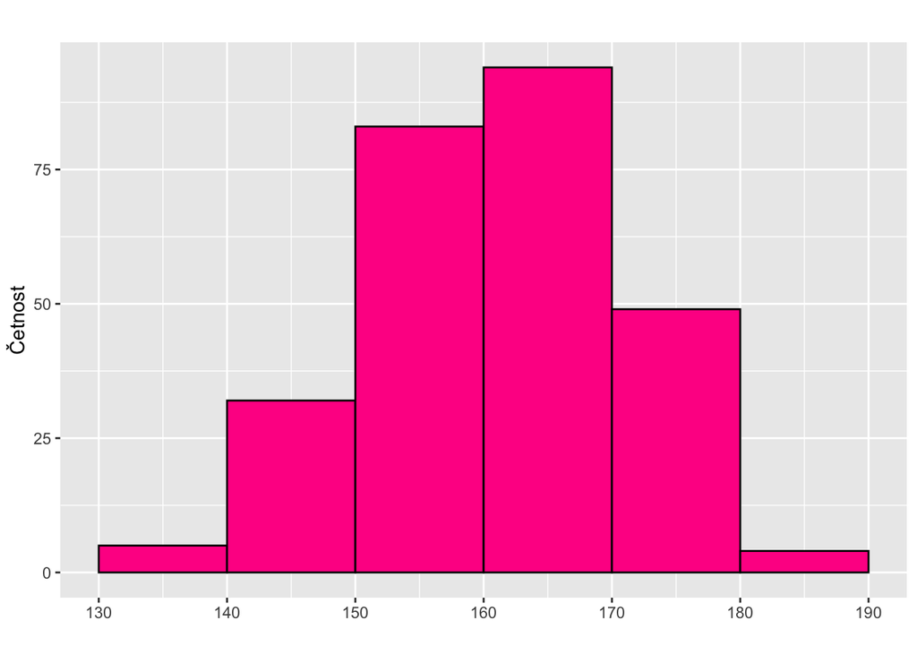

```r
df %>%
  ggplot(aes(x = VYSKA)) +
  geom_histogram(breaks = seq(130, 190, 10),                 # dílky histogramu
                 color="black",
                 fill = "deeppink") +
  scale_x_continuous(breaks = seq(130,190,10)) +           # osa histogramu
  labs(title = "", x = "", y = "Četnost") +
  theme(plot.title = element_text(face = "bold"))
```

### Histogram s jádrovým odhadem hustoty

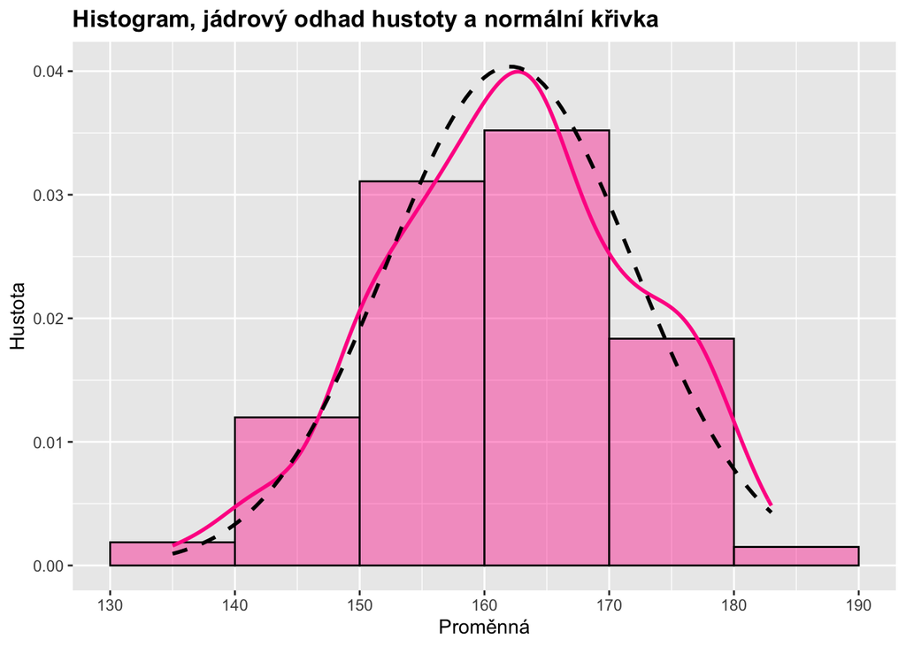

```r
promenna <- df$VYSKA

prumer <- mean(promenna, na.rm = TRUE)
sm_odch <- sd(promenna, na.rm = TRUE)


df %>%
  ggplot(aes(x = VYSKA)) +

  geom_histogram(breaks = seq(130, 190, 10),
                 color = "black",
                 fill = "deeppink",
                 aes(y = after_stat(density)),
                 alpha = 0.4) +

  geom_density(color = "deeppink", size = 1) +

  stat_function(fun = dnorm, args = list(mean = prumer, sd = sm_odch),
                color = "black", size = 1, linetype = "dashed") +

  scale_x_continuous(breaks = seq(130, 190, 10)) +
  labs(title = "Histogram, jádrový odhad hustoty a normální křivka",
       x = "Proměnná",
       y = "Hustota") +
  theme(plot.title = element_text(face = "bold"))
```

### Boxplot

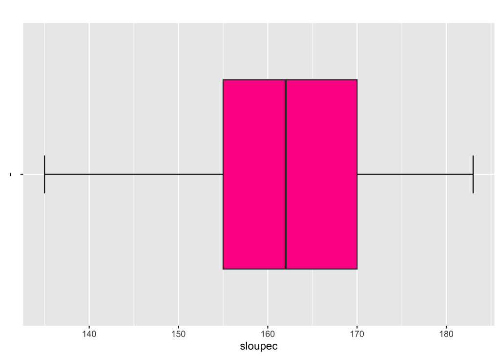

```r
df %>%
  ggplot(aes(x="", y=VYSKA)) +
  stat_boxplot(geom = "errorbar", width = 0.15) +
  geom_boxplot(outlier.shape = 20, outlier.size = 3, fill = "deeppink") +
  theme(legend.position="right") +
  labs(title= "", x="-", y="sloupec") +
  theme(plot.title = element_text(face = "bold")) +
  coord_flip()
```

### QQ plot

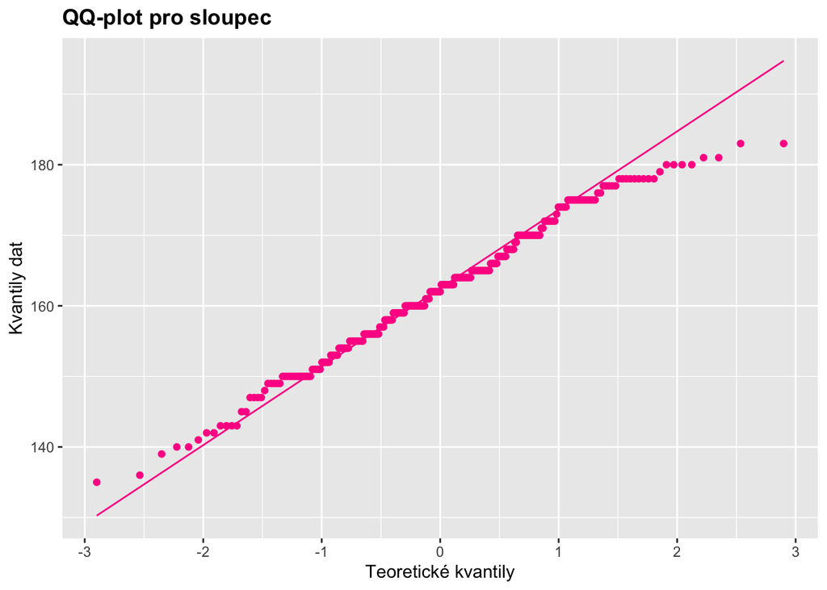

```r
sloupec <- df$VYSKA
df %>%
  ggplot(aes(sample = sloupec)) +
  geom_qq(color="deeppink") +
  stat_qq_line(color="deeppink") +
  labs(title = "QQ-plot pro sloupec", x = "Teoretické kvantily", y = "Kvantily dat") +
  theme(plot.title = element_text(face = "bold"))
```

## Šikmost, špičatost

**Šikmost**

```r
promenna <- df$VYSKA
skewness(promenna)
```

```
[1] -0.1407902
```

**Interpretace**:

- **B1 > 0** … pozitivní zešikmení; pravá(vyšší) ocasnost; více hodnot na pravé straně průměru
- **B1 < 0** … negativní zešikmení; levá(nižší) ocasnost; více hodnot na levé straně průměru
- **B1 = 0** … symetrická distribuce; jako normální rozdělení

**Špičatost**

```r
promenna <- df$VYSKA
kurtosis(promenna)
```

```
[1] 2.598292
```

**Interpretace**:

- **B2 > 0** … špičatější; leptokurtické rozdělení; vysoká koncentrace hodnot okolo modusu a tučné ocasy - početný výskyt vzdálených hodnot
- **B2 < 0** … plošší; platykurtické rozdělení; nízká koncentrace hodnot okolo modusu s tenkými konci
- **B2 = 0** … mezokurtické rozdělení; jako normální rozdělení

### Robustní přístupy k šikmosti a špičatosti

```r
medianovy_koeficient_sikmosti <- function(x, na.rm = TRUE) {
  if (na.rm) x <- na.omit(x)
  mean_x <- mean(x)
  median_x <- median(x)
  sd_x <- sd(x)
  skewness <- 3 * (mean_x - median_x) / sd_x
  return(skewness)
}
medianovy_koeficient_spicatosti <- function(x, na.rm = TRUE) {
  if (na.rm) x <- na.omit(x)
  q1 <- quantile(x, 0.25)
  q3 <- quantile(x, 0.75)
  q10 <- quantile(x, 0.1)
  q90 <- quantile(x, 0.9)
  n <- length(x)
  kurtosis <- (q3 - q1) / (2 * (q90 - q10)) * (n / (n - 1))
  return(kurtosis)
}

promenna <- df$VYSKA
medianovy_koeficient_sikmosti(promenna)
```

```
[1] 0.02160585
```

```r
medianovy_koeficient_spicatosti(promenna)
```

```
      75%
0.3011278
```

```r
promenna <- df$VYSKA
promenna_normovana <- scale(promenna)
normovani <- data.frame(promenna, promenna_normovana)
head(normovani,5)
```

```
  promenna promenna_normovana
1      160         -0.2096147
2      165          0.2964171
3      172          1.0048616
4      169          0.7012425
5      159         -0.3108210
```

```r
# jak daleko je jendotka od průměru v jednotkách směrodatné odchylky
```

## Shapiro-Wilkův test normality

- **Nulová hypotéza**: Data mají normální rozdělení.
- **Alternativní hypotéza**: Data nemají normální rozdělení.
- **Hladina významnosti**: 0.05 (případně 0.1 nebo 0.01)

```r
promenna <- df$VYSKA
shapiro.test(sample(promenna,100))
```

```
    Shapiro-Wilk normality test

data:  sample(promenna, 100)
W = 0.9848, p-value = 0.307
```

- **W =** : Čím je hodnota blíže k 1, tím více jsou data podobná normálnímu rozdělení
- **p-value =** : určuje, zda můžeme zamítnout nulovou hypotézu
  1. p-value > hladina významnosti - data jsou normálně rozdělena
  2. p-value < hladina významnosti - data nejsou normálně rozdělena

## Alternativy Shapirovo-Wilkova testu

```r
library(nortest)
library(DescTools)

promenna <- df$VYSKA
# pro použití na malých vzorcích, kde neznáme mean a sd
lillie.test(promenna)
```

```
    Lilliefors (Kolmogorov-Smirnov) normality test

data:  promenna
D = 0.047385, p-value = 0.1528
```

```r
# založen na kumulativní distribuční funkci, citlivější na odchylky v ocasech
ad.test(promenna)
```

```
    Anderson-Darling normality test

data:  promenna
A = 0.64673, p-value = 0.09061
```

```r
AndersonDarlingTest(promenna, null = "pnorm", mean = mean(promenna), sd = sd(promenna))
```

```
    Anderson-Darling test of goodness-of-fit
    Null hypothesis: Normal distribution
    with parameters mean = 162.071, sd = 9.881

data:  promenna
An = 0.64673, p-value = 0.6048
```

# Identifikace odlehlých hodnot

```r
library(tidyverse)
library(readxl)
df <- read_excel("/Users/majdikleckerova/Desktop/DataDetiMin.xlsx")
```

**Odlehlé hodnoty (outliery)** jsou hodnoty v datové sadě, které jsou výrazně odlišné od většiny ostatních pozorování. Mohou být způsobeny **chybou v měření**, **náhodnými událostmi** nebo mohou představovat **skutečné extrémy v datech**. Identifikace je velmi důležitá, protože odlehlé hodnoty mohou **výrazně ovlivnit** statistické odhady a analýzy.

**Reakce na existenci outlierů**:

- **Odstranění**: Identifikace a fyzické odstranění odlehlých hodnot; riskantní.
- **Transformace dat**: Zmírnit vliv odlehlých hodnot na analýzu.
- **Robustní metody**: Použít statistické metody navržené tak, aby byly odolné vůči odlehlým hodnotám (např. medián místo průměru).
- **Vizualizace**: Použít grafické nástroje, jako je boxplot, Q-Q plot nebo histogram k identifikaci odlehlých hodnot.

**Způsoby identifikace**:

- **Vizualizace**

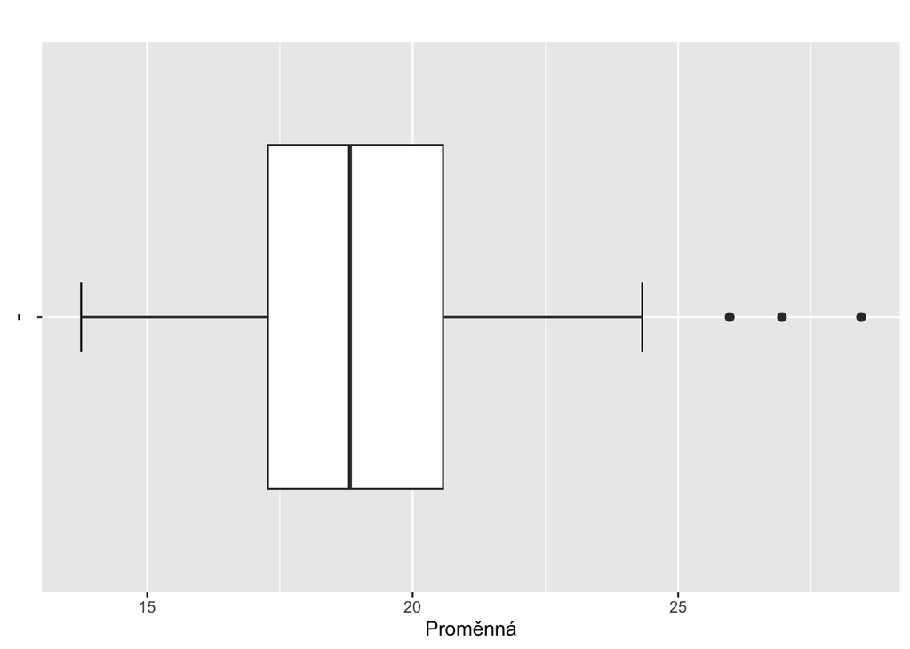

```r
df %>%
  ggplot(aes(x="", y=BMI)) +
  stat_boxplot(geom = "errorbar", width = 0.15, coef=1.5) +
  geom_boxplot(outlier.shape = 20, outlier.size = 3) +
  theme(legend.position="right") +
  labs(title= "", x="-", y="Proměnná") +
  theme(plot.title = element_text(face = "bold")) +
  coord_flip()
```

**Odléhlé hodnoty** jsou v boxplotu zobrazeny jako **samostatné body** mimo “tykadla”(whiskers) grafu.

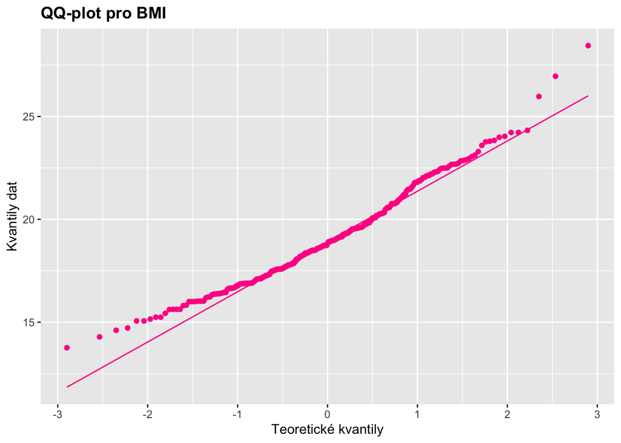

```r
df %>%
  ggplot(aes(sample = BMI)) +
  geom_qq(color="deeppink") +
  stat_qq_line(color="deeppink") +
  labs(title = "QQ-plot pro BMI", x = "Teoretické kvantily", y = "Kvantily dat") +
  theme(plot.title = element_text(face = "bold"))
```

Za **odlehlé body** mohou být považovány body, které se výrazně odchylují od diagonální přímky, na začátku nebo na konci grafu.

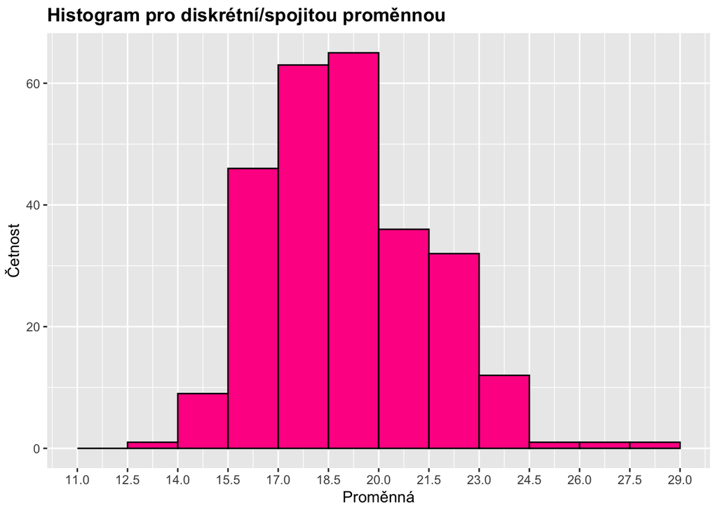

```r
promenna <- df$BMI
df %>%
  ggplot(aes(x = promenna)) +
  geom_histogram(breaks = seq(11,30,1.5),
                 color="black",
                 fill = "deeppink") +
  scale_x_continuous(breaks = seq(11,30,1.5)) +
  labs(title = "Histogram pro diskrétní/spojitou proměnnou", x = "Proměnná", y = "Četnost") +
  theme(plot.title = element_text(face = "bold"))
```

**Odlehlé hodnoty** se často objevují jako **samostatné sloupce** na okrajích distribuce. V případě zešikmení je obtížné je někdy najít, mohou se nacházet v ocasu. Musíme transformovat na symetrická data;

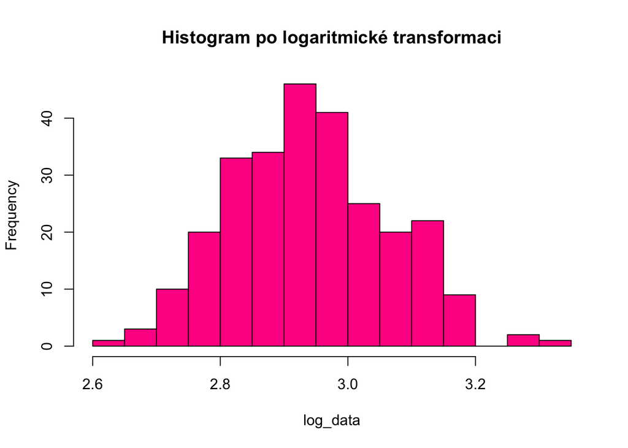

```r
data <- df$BMI
log_data <- log(data)
hist(log_data, breaks = 12, col = "deeppink", main = "Histogram po logaritmické transformaci")  # Nastavení počtu binů jako u původního
```

**Interkvartilový rozsah (IQR)**

- **IQR** měří rozsah mezi **dolním** a **horním** kvartilem dat.
- Outliery obvykle leží mimo rozsah **Q1 - 1.5 * IQR** a **Q3 + 1.5 * IQR**
- **robustní vůči normálnímu rozdělení**

```r
promenna <- df$BMI

Q1 <- quantile(promenna, 0.25)
Q3 <- quantile(promenna, 0.75)

IQR <- Q3 - Q1

dolni_mez <- Q1 - 1.5 * IQR
horni_mez <- Q3 + 1.5 * IQR

outliers <- promenna[promenna < dolni_mez | promenna > horni_mez]
outliers
```

```
[1] 26.95312 25.97012 28.44444
```

**Z-Skóre**

- Z-Skóre měří, jak daleko je pozorování od **průměru dat** v jednotkách standardní odchylky (1.5-násobek, 2-násobek)
- **z-skóre dané hodnoty x:** z = (x - mean(x)) / sd
- Outliery jsou obvykle považovány za ty, které mají Z-Skóre **přesahující** určitý práh (2 nebo 3)

```r
promenna <- df$BMI

mean <- mean(promenna)
sd <- sd(promenna)

z_score <- (promenna - mean) / sd

outliers <- promenna[abs(z_score) > 3]

cat("\nOdlehlé hodnoty (Z-skóre > 3 nebo < -3):\n")
```

```
Odlehlé hodnoty (Z-skóre > 3 nebo < -3):
```

```r
print(outliers)
```

```
[1] 26.95312 28.44444
```